# Penalized_regression

## Bias-variance tradeoff

- One goal of a regression analysis is to "build" a model that predicts well -- AIC / $C_p$ & Cross-validation selection criteria based on this.
- This is slightly different than the goal of making inferences about $\beta$ that we've focused on so far.
- What does "predict well" mean? $$ \begin{aligned} MSE_{pop}({{\cal M}}) &= {\mathbb{E}}\left((Y_{new} - \widehat{Y}_{new,{\cal M}}(X_{new}))^2\right) \\ &= {\text{Var}}(Y_{new}) + {\text{Var}}(\widehat{Y}_{new,{\cal M}}) + \\ & \qquad \quad \text{Bias}(\widehat{Y}_{new,{\cal M}})^2. \end{aligned}$$
- Can we take an estimator for a model ${\cal M}$ and make it better in terms of $MSE$?

```r
options(repr.plot.width=5, repr.plot.height=5)
```

## Shrinkage estimators: one sample problem

1. Generate $Y_{100 \times 1} \sim N(\mu \cdot 1, 5^2 I_{100 \times 100})$, with $\mu=0.5$.
2. For $0 \leq \alpha \leq 1$, set $\hat{Y}(\alpha) = \alpha \bar{Y}.$
3. Compute $MSE(\hat{Y}(\alpha)) = \frac{1}{100}\sum_{i=1}^{100} (\hat{Y}_{\alpha} - 0.5)^2$
4. Repeat 1000 times, plot average of $MSE(\hat{Y}(\alpha))$.

**For what value of $\alpha$ is $\hat{Y}(\alpha)$ unbiased?**

**Is this the best estimate of $\mu$ in terms of MSE?**

```r
mu = 0.5
sigma = 5
nsample = 100
ntrial = 1000

MSE = function(mu.hat, mu) {
  return(sum((mu.hat - mu)^2) / length(mu))
}
```

```r
alpha = seq(0,1,length=20)
mse = numeric(length(alpha))
bias = (1 - alpha) * mu
variance = alpha^2 * 25 / 100

for (i in 1:ntrial) {
  Z = rnorm(nsample) * sigma + mu
  for (j in 1:length(alpha)) {
    mse[j] = mse[j] + MSE(alpha[j] * mean(Z) * rep(1, nsample), mu * rep(1, nsample))
  }
}
mse = mse / ntrial
```

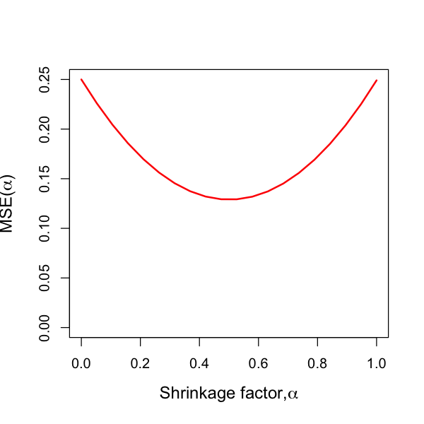

```r
plot(alpha, mse, type='l', lwd=2, col='red', ylim=c(0, max(mse)),
     xlab=expression(paste('Shrinkage factor,', alpha)),
     ylab=expression(paste('MSE(', alpha, ')')),
     cex.lab=1.2)
```

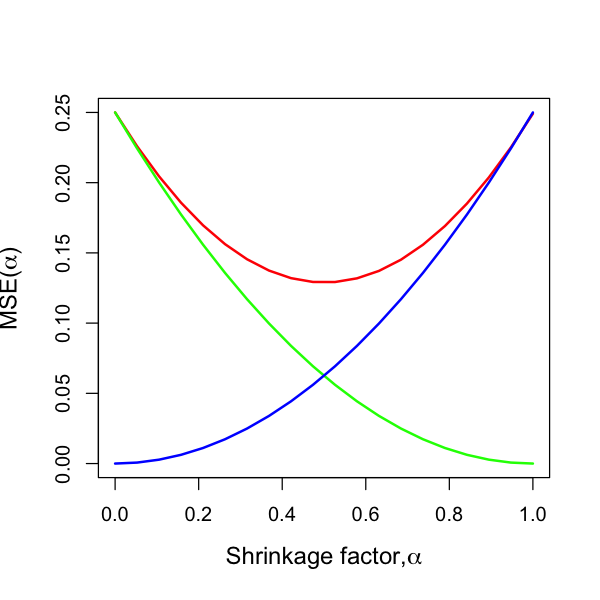

```r
plot(alpha, mse, type='l', lwd=2, col='red', ylim=c(0, max(mse)),
     xlab=expression(paste('Shrinkage factor,', alpha)),
     ylab=expression(paste('MSE(', alpha, ')')),
     cex.lab=1.2)
lines(alpha, bias^2, col='green', lwd=2)
lines(alpha, variance, col='blue', lwd=2)
```

## Shrinkage & Penalties

- Shrinkage can be thought of as "constrained" or "penalized" minimization.
- Constrained form: $$\text{minimize}_{\mu} \sum_{i=1}^n (Y_i - \mu)^2 \quad \text{subject to $\mu^2 \leq C$}$$
- Lagrange multiplier form: equivalent to $$\widehat{\mu}_{\lambda} = \text{argmin}_{\mu} \sum_{i=1}^n (Y_i - \mu)^2 + \lambda \cdot \mu^2$$ for some $\lambda=\lambda_C$.
- As we vary $\lambda$ we solve all versions of the constrained form.

### Solving for $\widehat{\mu}_{\lambda}$

- Differentiating: $- 2 \sum_{i=1}^n (Y_i - \widehat{\mu}_{\lambda}) + 2 \lambda \widehat{\mu}_{\lambda} = 0$
- Solving $\widehat{\mu}_{\lambda} = \frac{\sum_{i=1}^n Y_i}{n + \lambda} = \frac{n}{n+\lambda} \overline{Y}.$
- As $\lambda \rightarrow 0$, $\widehat{\mu}_{\lambda} \rightarrow {\overline{Y}}.$
- As $\lambda \rightarrow \infty$ $\widehat{\mu}_{\lambda} \rightarrow 0.$

**We see that $\widehat{\mu}_{\lambda} = \bar{Y} \cdot \left(\frac{n}{n+\lambda}\right).$**

**In other words, considering all penalized estimators traces out the MSE curve above.**

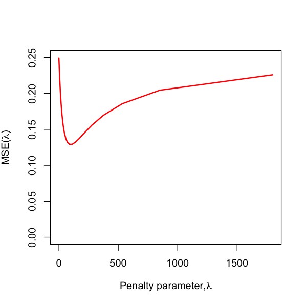

```r
lam = nsample / alpha - nsample
plot(lam, mse, type='l', lwd=2, col='red', ylim=c(0, max(mse)),
     xlab=expression(paste('Penalty parameter,',  lambda)),
     ylab=expression(paste('MSE(', lambda, ')')))
```

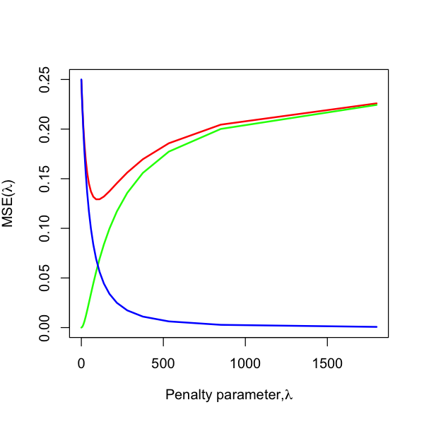

```r
plot(lam, mse, type='l', lwd=2, col='red', ylim=c(0, max(mse)),
     xlab=expression(paste('Penalty parameter,',  lambda)),
     ylab=expression(paste('MSE(', lambda, ')')))
lines(lam, bias^2, col='green', lwd=2)
lines(lam, variance, col='blue', lwd=2)
```

### How much to shrink?

- In our one-sample example,
- $$\begin{aligned} MSE_{pop}(\alpha) &= {\text{Var}}( \alpha \bar{Y}) + \text{Bias}(\alpha \bar{Y})^2 + \text{Var}(Y_{new}) \\ &= \frac{\alpha^2 \sigma^2}{n} + \mu^2 (1 - \alpha)^2 + \text{Var}(Y_{new}) \end{aligned}$$
- Differentiating and solving: $$\begin{aligned} 0 &= -2 \mu^2(1 - \alpha^*) + 2 \frac{\alpha^* \sigma^2}{n} \\ \alpha^* & = \frac{\mu^2}{\mu^2+\sigma^2/n} = \frac{(\mu/(\sigma/\sqrt{n}))^2}{(\mu/(\sigma/\sqrt{n}))^2 + 1} \\ &= \frac{0.5^2}{0.5^2+25/100} = 0.5 \end{aligned}$$

**In practice we might hope to estimate MSE with cross-validation.**

Let's see how our theoretical choice matches the MSE on our 100 sample.

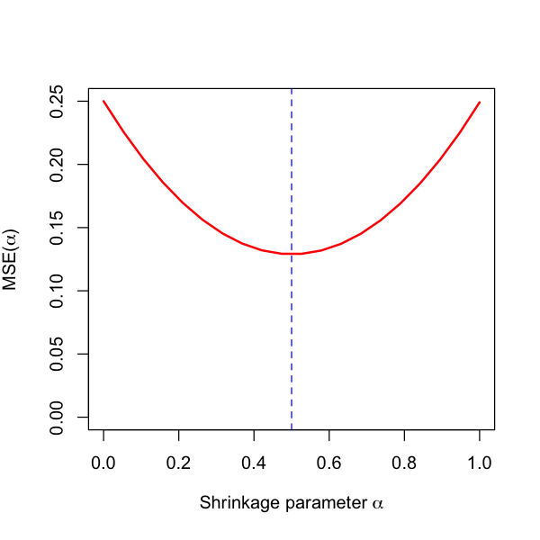

```r
plot(alpha, mse, type='l', lwd=2, col='red', ylim=c(0, max(mse)),
     xlab=expression(paste('Shrinkage parameter ', alpha)),
     ylab=expression(paste('MSE(', alpha, ')')))
abline(v=mu^2/(mu^2+sigma^2/nsample), col='blue', lty=2)
```

### Penalties & Priors

- Minimizing $\sum_{i=1}^n (Y_i - \mu)^2 + \lambda \mu^2$ is similar to computing "MLE" of $\mu$ if the likelihood was proportional to $$\exp \left(-\frac{1}{2\sigma^2}\left( \|Y-\mu\|^2_2 + \lambda \mu^2\right) \right).$$
- If $\lambda=m$, an integer, then $\widehat{\mu}_{\lambda}$ is the sample mean of $(Y_1, \dots, Y_n,0 ,\dots, 0) \in \mathbb{R}^{n+m}$.
- This is equivalent to adding some data with $Y=0$.
- To a Bayesian, this extra data is a *prior distribution* and we are computing the so-called *MAP* or posterior mode.

## AIC as penalized regression

- Model selection with $C_p$ (or AIC with $\sigma^2$ assumed known) is a version of penalized regression.
- The best subsets version of AIC (which is not exactly equivalent to *step*) $$ \hat{\beta}_{AIC} = \text{argmin}_{\beta} \frac{1}{\sigma^2}\|Y-X\beta\|^2_2 + 2 \|\beta\|_0 $$ where $$ \|\beta\|_0 = \#\left\{j : \beta_j \neq 0 \right\} $$ is called the $\ell_0$ norm.
- The $\ell_0$ penalty can be thought of as a measure of *complexity* of the model. Most penalties are similar versions of *complexity*.

## Penalized regression in general

- Not all biased models are better – we need a way to find "good" biased models.
- Inference ($F$, $\chi^2$ tests, etc) is not quite exact for biased models. Though, there has been some recent work to address the issue of [post-selection inference](http://arxiv.org/abs/1311.6238), at least for some penalized regression problems.
- Heuristically, "large $\beta$" (measured by some norm) is interpreted as "complex model". Goal is really to penalize "complex" models, i.e. Occam’s razor.
- If truth really is complex, this may not work! (But, it will then be hard to build a good model anyways ... (statistical lore))

## Ridge regression

- Assume that columns $(X_j)_{1 \leq j \leq p}$ have zero mean, and SD 1 and $Y$ has zero mean.
- This is called the *standardized model*.
- The ridge estimator is $$ \begin{aligned} \hat{\beta}_{\lambda} &= \text{argmin}_{\beta} \frac{1}{2n}\|Y-X\beta\|^2_2 + \frac{\lambda}{2} \|\beta\|^2_2 \\ &= \text{argmin}_{\beta} MSE_{\lambda}(\beta) \end{aligned} $$
- Corresponds (through Lagrange multiplier) to a quadratic constraint on ${\beta_{}}$’s.
- This is the natural generalization of the penalized version of our shrinkage estimator.

### Solving the normal equations

- Normal equations $$\frac{\partial}{\partial {\beta_{l}}} MSE_{\lambda}({\beta_{}}) = - \frac{1}{n} (Y - X{\beta_{}})^TX_l + \lambda {\beta_{l}}$$
- $$- \frac{1}{n}(Y - X{\widehat{\beta}_{\lambda}})^T X_l + \lambda {\widehat{\beta}_{l,\lambda}} = 0, \qquad 1 \leq l \leq p$$
- In matrix form $$-\frac{X^TY}{n} + \left(\frac{X^TX}{n} + \lambda I\right) {\widehat{\beta}_{\lambda}} = 0.$$
- Or $${\widehat{\beta}_{\lambda}} = \left(\frac{X^TX}{n} + \lambda I\right)^{-1} \frac{X^TY}{n}.$$

### Ridge regression

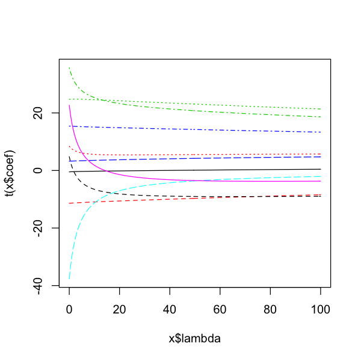

```r
library(lars)
data(diabetes)
library(MASS)
diabetes.ridge = lm.ridge(diabetes$y ~ diabetes$x,
                          lambda=seq(0, 100, 0.5))
plot(diabetes.ridge, lwd=3)
```

### Choosing $\lambda$

- If we knew $E[MSE_{\lambda}]$ as a function of $\lambda$ then we would simply choose the $\lambda$ that minimizes it.
- To do this, we need to estimate it.
- A popular method is cross-validation as a function of $\lambda$. Breaks the data up into smaller groups and uses part of the data to predict the rest.
- We saw this in diagnostics (Cook’s distance measured the fit with and without each point in the data set) and model selection.

### $K$-fold cross-validation for penalized model

- Fix a model (i.e. fix $\lambda$). Break data set into $K$ approximately equal sized groups $(G_1, \dots, G_K)$.
- for (i in 1:K) Use all groups except $G_i$ to fit model, predict outcome in group $G_i$ based on this model $\widehat{Y}_{j(i),\lambda}, j \in G_i$.
- Estimate $CV(\lambda) = \frac{1}{n}\sum_{i=1}^K \sum_{j \in G_i} (Y_j - \widehat{Y}_{j(i),\lambda})^2.$

```r
CV = function(Z, alpha, K=5) {
    cve = numeric(K)
    n = length(Z)
    for (i in 1:K) {
        g = seq(as.integer((i-1)*n/K)+1,as.integer((i*n/K)))
        mu.hat = mean(Z[-g]) * alpha
        cve[i] = sum((Z[g]-mu.hat)^2)
    }
    return(c(sum(cve) / n, sd(cve) / sqrt(n)))
}
```

Let's see how the parameter chosen by 5-fold CV compares to our theoretical choice.

```r
alpha = seq(0.0,1,length=20)
mse = numeric(length(alpha))
avg.cv = numeric(length(alpha))
for (i in 1:ntrial) {
     Z = rnorm(nsample) * sigma + mu
     for (j in 1:length(alpha)) {
         current_cv = CV(Z, alpha[j])
         avg.cv[j] = avg.cv[j] + current_cv[1]
     }
}
avg.cv = avg.cv / ntrial
```

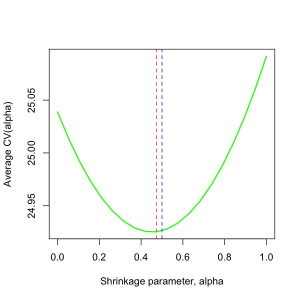

```r
plot(alpha, avg.cv, type='l', lwd=2, col='green',
     xlab='Shrinkage parameter, alpha', ylab='Average CV(alpha)')
abline(v=mu^2/(mu^2+sigma^2/nsample), col='blue', lty=2)
abline(v=min(alpha[avg.cv == min(avg.cv)]), col='red', lty=2)
```

The curve above shows what would happen if we could repeat this and average over many samples. In reality, we only get one sample.

Let's see what one curve looks like on our sample. This is the result we might get in practice on a given data set.

```r
cv = numeric(length(alpha))
cv.sd = numeric(length(alpha))
Z = rnorm(nsample) * sigma + mu
for (j in 1:length(alpha)) {
    current_cv = CV(Z, alpha[j])
    cv[j] = current_cv[1]
    cv.sd[j] = current_cv[2]
}
```

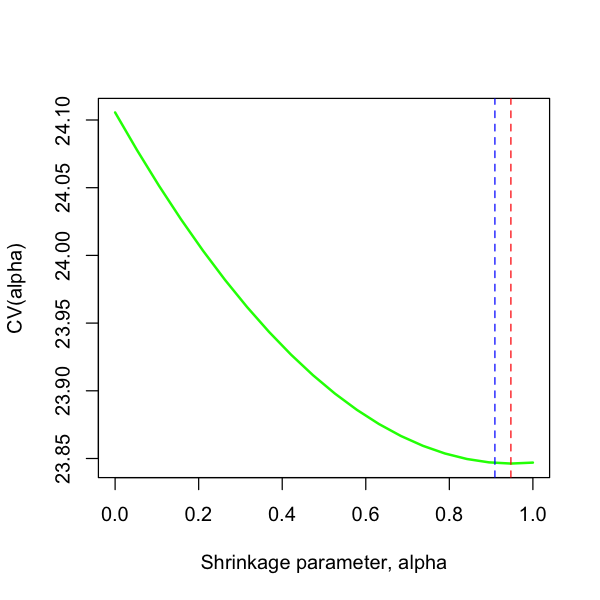

```r
cv = numeric(length(alpha))
cv.sd = numeric(length(alpha))
nsample = 1000
Z = rnorm(nsample) * sigma + mu
for (j in 1:length(alpha)) {
    current_cv = CV(Z, alpha[j])
    cv[j] = current_cv[1]
    cv.sd[j] = current_cv[2]
}
plot(alpha, cv, type='l', lwd=2, col='green',
    xlab='Shrinkage parameter, alpha', ylab='CV(alpha)', xlim=c(0,1))
 abline(v=mu^2/(mu^2+sigma^2/nsample), col='blue', lty=2)
 abline(v=min(alpha[cv == min(cv)]), col='red', lty=2)
```

### Generalized Cross Validation

- A computational shortcut for $n$-fold cross-validation (also known as leave-one out cross-validation).
- Let $S_{\lambda} = X(X^TX + n\lambda I)^{-1} X^T$ be the matrix in ridge regression that computes $\hat{Y}_{\lambda}$
- Then $GCV(\lambda) = \frac{\|Y - S_{\lambda}Y\|^2}{n - {\text{Tr}}(S_{\lambda})}.$
- The quantity ${\text{Tr}}(S_{\lambda})$ can be thought of as the *effective degrees of freedom* for this choice of $\lambda$.

### Ridge regression

```
modified HKB estimator is 5.462251
modified L-W estimator is 7.641667
smallest value of GCV  at 3
```

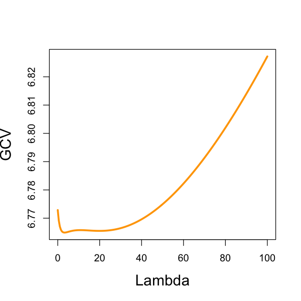

```r
par(cex.lab=1.5)
plot(diabetes.ridge$lambda, diabetes.ridge$GCV, xlab='Lambda',
     ylab='GCV', type='l', lwd=3, col='orange')
select(diabetes.ridge)
```

## LASSO

- Another popular penalized regression technique.
- Use the standardized model.
- The LASSO estimate is $$ \hat{\beta}_{\lambda} = \text{argmin}_{\beta} \frac{1}{2n}\|Y-X\beta\|^2_2 + \lambda \|\beta\|_1$$ where $$ \|\beta\|_1 = \sum_{j=1}^p |\beta_j| $$ is the $\ell_1$ norm.
- Corresponds (through Lagrange multiplier) to an $\ell_1$ constraint on ${\beta_{}}$’s.

## LASSO

- In theory and practice, it works well when many ${\beta_{j}}$’s are 0 and gives "sparse" solutions unlike ridge.
- It is a (computable) approximation to the best subsets AIC model.
- It is computable because the minimization problem is a convex problem.

### Why do we get sparse solutions with the LASSO?

[figure not shown]

## LASSO in 1-dimension

- Problem is: $$ \text{minimize}_{\beta \in \mathbb{R}} \frac{1}{2} (Z - \beta)^2 + \lambda |\beta|. $$
- We can see here that we sometimes get 0 as the solution.

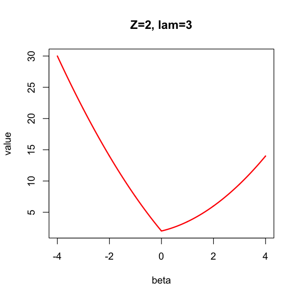

```r
Z = 2
lam = 3
beta = seq(-4, 4, length=801)
value = (beta - Z)^2/2 + lam * abs(beta)
plot(beta, value, type='l', lwd=2, col='red', main="Z=2, lam=3")
```

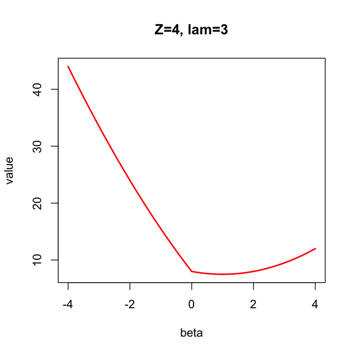

```r
Z = 4
lam = 3
beta = seq(-4, 4, length=801)
value = (beta - Z)^2/2 + lam * abs(beta)
plot(beta, value, type='l', lwd=2, col='red', main="Z=4, lam=3")
```

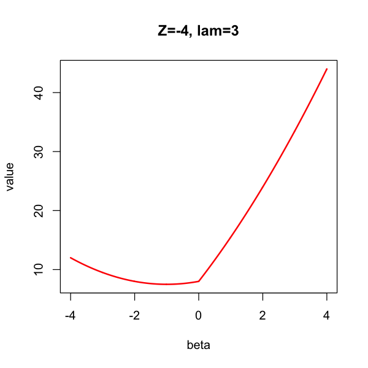

```r
Z = -4
lam = 3
beta = seq(-4, 4, length=801)
value = (beta - Z)^2/2 + lam * abs(beta)
plot(beta, value, type='l', lwd=2, col='red', main="Z=-4, lam=3")
```

## LASSO

### Soft-thresholding

- In 1-dimension, the solution is $$ \hat{\beta}_{\lambda}(Z) = \text{sign}(Z) \cdot \max(|Z| - \lambda , 0). $$
- If $X^TX/n = I$ (*(scaled) orthonormal columns*) then solution is component-wise soft-thresholding $$ \hat{\beta}_{\lambda}(X, Y) = \text{sign}(X_j^TY/n) \cdot \max(|X_j^TY|/n - \lambda, 0). $$
- For general $X$ a "vector" version of soft-thresholding -- generally some components are 0.

## LASSO

[figure not shown]

### LASSO

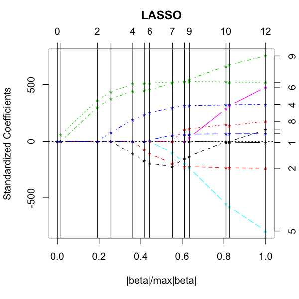

```r
library(lars)
data(diabetes)
diabetes.lasso = lars(diabetes$x, diabetes$y, type='lasso')
plot(diabetes.lasso)
```

### Cross-validation for the LASSO

The `lars` package has a built in function to estimate CV.

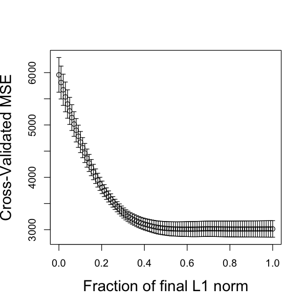

```r
par(cex.lab=1.5)
cv.lars(diabetes$x, diabetes$y, K=10, type='lasso')
```

## `glmnet`

```r
library(glmnet)
G = glmnet(diabetes$x, diabetes$y)
```

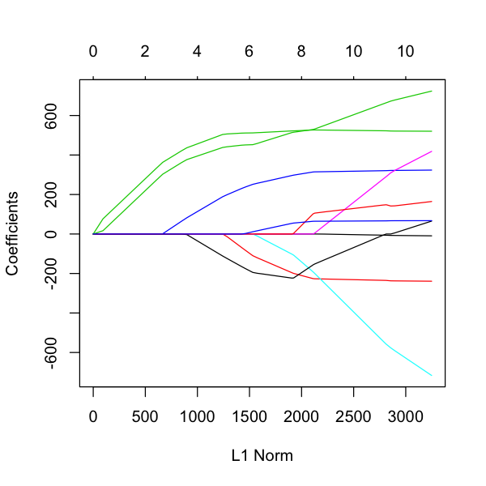

```r
plot(G)
```

5.83264216449909

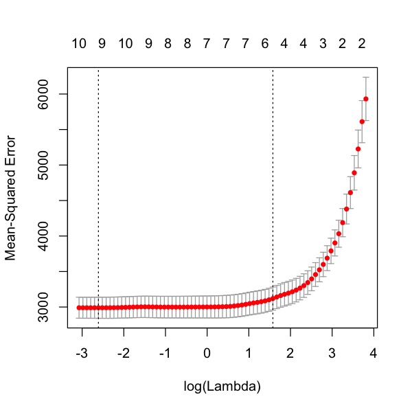

```r
plot(cv.glmnet(diabetes$x, diabetes$y))
cv.glmnet(diabetes$x, diabetes$y)$lambda.1se
```

```r
X_HIV = read.table('http://stats191.stanford.edu/data/NRTI_X.csv', header=FALSE, sep=',')
Y_HIV = read.table('http://stats191.stanford.edu/data/NRTI_Y.txt', header=FALSE, sep=',')
set.seed(0)
Y_HIV = as.matrix(Y_HIV)[,1]
X_HIV = as.matrix(X_HIV)
```

## HIV example

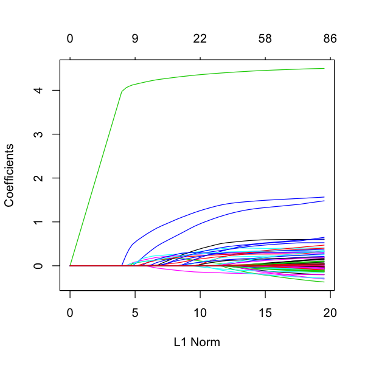

```r
library(glmnet)
G = glmnet(X_HIV, Y_HIV)
plot(G)
```

## HIV example

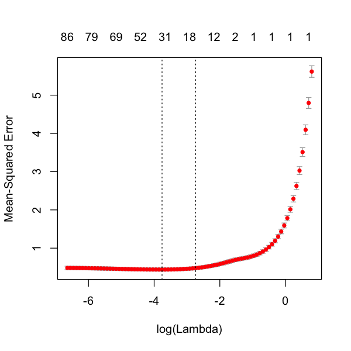

```r
CV = cv.glmnet(X_HIV, Y_HIV)
plot(CV)
```

## Extracting coefficients from `glmnet`

```r
beta.hat = coef(G, s=CV$lambda.1se)
beta.hat # might want to use as.numeric(beta.hat) instead of a sparse vector
```

```
92 x 1 sparse Matrix of class "dgCMatrix"
                      1
(Intercept)  0.59723946
V1           .
V2           .
V3           .
V4           .
V5           .
V6           .
V7           .
V8           .
V9           .
V10          .
V11          .
V12          .
V13          .
V14          .
V15          .
V16          0.16722766
V17          1.10295056
V18          .
V19          0.23659869
V20          .
V21          .
V22          .
V23          0.74501272
V24          .
V25          .
V26          .
V27          0.08150319
V28          .
V29          0.01228185
V30          0.27374025
V31         -0.11490020
V32          0.24461337
V33          .
V34          .
V35          .
V36          .
V37          .
```

[output cut: 39 more lines]

```
V77          .
V78          .
V79          .
V80          .
V81          0.13604627
V82          0.22817986
V83          .
V84          .
V85          .
V86          .
V87          0.18386030
V88          .
V89          .
V90          .
V91          .
```

### Elastic Net

- Mix between LASSO and ridge regression.
- Sometimes a more stable estimator than LASSO.
- The ENET estimator is $$ \hat{\beta}_{\lambda, \alpha} = \text{argmin}_{\beta} \frac{1}{2n} \|Y-X\beta\|^2_2 + \lambda \left(\alpha \|\beta\|_1 + (1 - \alpha) \|\beta\|^2_2 \right).$$

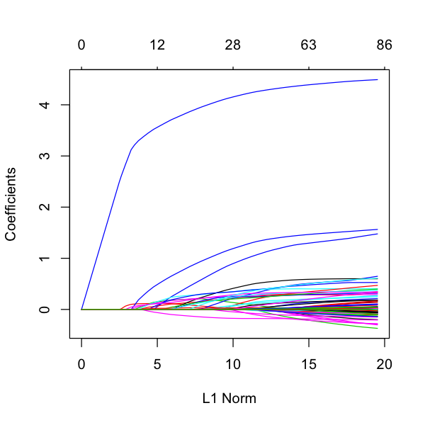

```r
plot(glmnet(X_HIV, Y_HIV, alpha=0.25))
```

## Ridge regression

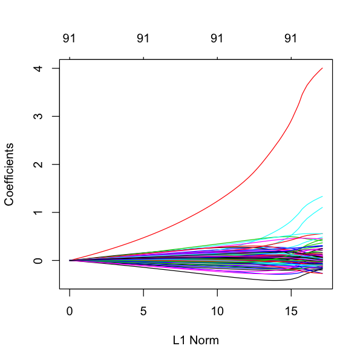

```r
plot(glmnet(X_HIV, Y_HIV, alpha=0))
```